# Tugas Praktikum 3

Diani Raras Puspita

2025-09-04

## Pemanggilan Packages

```r
library(dplyr)
library(TTR)
library(forecast)
library(lmtest) #digunakan untuk uji formal pendeteksian autokorelasi
library(orcutt) #untuk membuat model regresi Cochrane-Orcutt
library(HoRM) #untuk membuat model regresi Hildreth-Lu
```

# Input Data

Data yang digunakan dalam tugas ini adalah data IPM Provinsi Papua periode tahun 2010-2021.

## Data IPM Papua

```r
# Buat data IPM Papua
tahun <- c(2010,2011,2012,2013,2014,2015,2016,2017,
           2018,2019,2020,2021,2022,2023)

ipm <- c(54.55,55.01,55.55,56.25,56.75,
         57.25,58.05,59.09,60.06,60.84,
         61.22,61.40,62.16,63.01)

dtPapua <- cbind(tahun, ipm)
dtPapua <- as.data.frame(dtPapua)
dtPapua
```

```
##    tahun   ipm
## 1   2010 54.55
## 2   2011 55.01
## 3   2012 55.55
## 4   2013 56.25
## 5   2014 56.75
## 6   2015 57.25
## 7   2016 58.05
## 8   2017 59.09
## 9   2018 60.06
## 10  2019 60.84
## 11  2020 61.22
## 12  2021 61.40
## 13  2022 62.16
## 14  2023 63.01
```

## Membentuk Objek Time Series

```r
# Membentuk objek time series dari data IPM Papua
dataPapua.ts <- ts(dtPapua$ipm, start = 2010, frequency = 1)
dataPapua.ts
```

```
## Time Series:
## Start = 2010
## End = 2023
## Frequency = 1
##  [1] 54.55 55.01 55.55 56.25 56.75 57.25 58.05 59.09 60.06 60.84 61.22 61.40
## [13] 62.16 63.01
```

## Membuat Plot Time Series

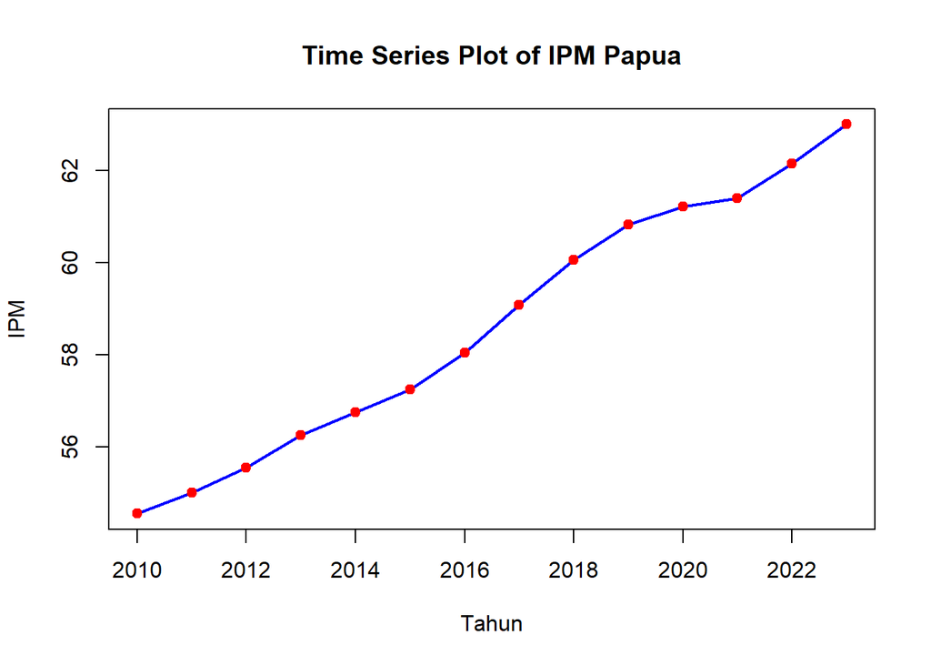

```r
# Membuat plot time series IPM Papua
ts.plot(dataPapua.ts,
        xlab = "Tahun",
        ylab = "IPM",
        main = "Time Series Plot of IPM Papua",
        col = "blue", lwd = 2)

# Tambahkan titik data biar lebih jelas
points(dataPapua.ts, col = "red", pch = 19)
```

Selanjutnya akan dilakukan ramalan dan pemulusan dengan metode DMA dan DES karena terlihat pada plot di atas menunjukkan adanya *trend*.

## Peramalan dengan Double Moving Average

```r
dt.sma <- SMA(dataPapua.ts, n=3)
dma <- SMA(dt.sma, n = 3)
At <- 2*dt.sma - dma
Bt <- 2/(3-1)*(dt.sma - dma)
dt.dma <- At+Bt
dt.ramal <- c(NA, dt.dma)

t = 1:5
f = c()

for (i in t) {
  f[i] = At[length(At)] + Bt[length(Bt)]*(i)
}
```

## Gabungan Data Aktual, Pemulusan, dan Ramalan

```r
dt.gab <- cbind(aktual = c(dataPapua.ts, rep(NA,5)),
                pemulusan1 = c(dt.sma, rep(NA,5)),
                pemulusan2 = c(dt.dma, rep(NA,5)),
                At = c(At, rep(NA,5)),
                Bt = c(Bt, rep(NA,5)),
                ramalan = c(dt.ramal, f[-1]))
dt.gab
```

```
##       aktual pemulusan1 pemulusan2       At        Bt  ramalan
##  [1,]  54.55         NA         NA       NA        NA       NA
##  [2,]  55.01         NA         NA       NA        NA       NA
##  [3,]  55.55   55.03667         NA       NA        NA       NA
##  [4,]  56.25   55.60333         NA       NA        NA       NA
##  [5,]  56.75   56.18333   57.33444 56.75889 0.5755556       NA
##  [6,]  57.25   56.75000   57.89222 57.32111 0.5711111 57.33444
##  [7,]  58.05   57.35000   58.52778 57.93889 0.5888889 57.89222
##  [8,]  59.09   58.13000   59.57000 58.85000 0.7200000 58.52778
##  [9,]  60.06   59.06667   60.83556 59.95111 0.8844444 59.57000
## [10,]  60.84   59.99667   61.86111 60.92889 0.9322222 60.83556
## [11,]  61.22   60.70667   62.27333 61.49000 0.7833333 61.86111
## [12,]  61.40   61.15333   62.22222 61.68778 0.5344444 62.27333
## [13,]  62.16   61.59333   62.47778 62.03556 0.4422222 62.22222
## [14,]  63.01   62.19000   63.27889 62.73444 0.5444444 62.47778
## [15,]     NA         NA         NA       NA        NA 63.27889
## [16,]     NA         NA         NA       NA        NA 63.82333
## [17,]     NA         NA         NA       NA        NA 64.36778
## [18,]     NA         NA         NA       NA        NA 64.91222
## [19,]     NA         NA         NA       NA        NA 65.45667
```

[figure not shown]

```r
# Plot time series
ts.plot(dt.gab[,1], xlab="Time Period ", ylab="IPM",
        main= "DMA N=3 Data IPM Papua", ylim=c(62,75))
points(dt.gab[,1])
points(dt.gab[,3])
points(dt.gab[,6])
lines(dt.gab[,3], col="green", lwd=2)
lines(dt.gab[,6], col="red", lwd=2)
legend("topleft", c("data aktual","data pemulusan","data peramalan"),
       lty=8, col=c("black","green","red"), cex=0.8)
```

Selanjutnya akan dilihat keakuratan dari metode DMA

## Menghitung Nilai Keakuratan

```r
error.dma = dataPapua.ts - dt.ramal[1:length(dataPapua.ts)]
SSE.dma = sum(error.dma[6:length(dataPapua.ts)]^2)
MSE.dma = mean(error.dma[6:length(dataPapua.ts)]^2)
MAPE.dma = mean(abs((error.dma[6:length(dataPapua.ts)]/dataPapua.ts[6:length(dataPapua.ts)])*100))

akurasi.dma <- matrix(c(SSE.dma, MSE.dma, MAPE.dma))
row.names(akurasi.dma) <- c("SSE", "MSE", "MAPE")
colnames(akurasi.dma) <- c("Akurasi m = 3")
akurasi.dma
```

```
##      Akurasi m = 3
## SSE      2.0491049
## MSE      0.2276783
## MAPE     0.6231418
```

Selanjutnya akan digunakan metode *Double Exponential Smoothing* dengan cara sebagai berikut.

Pertama akan data akan dibagi menjadi data *training* dan data *testing*.

## Membagi Data Training dan Testing

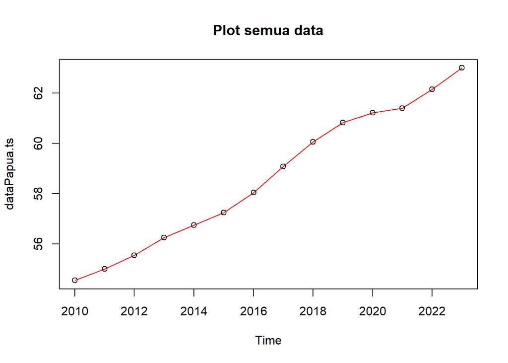

```r
# Membagi training (10 data pertama) dan testing (sisa 4 data)
training <- dtPapua[1:10, 2]
testing  <- dtPapua[11:14, 2]

# Data time series
training.ts <- ts(training)
testing.ts  <- ts(testing, start = 11)

# Eksplorasi data
plot(dataPapua.ts, col="red", main="Plot semua data")
points(dataPapua.ts)
```

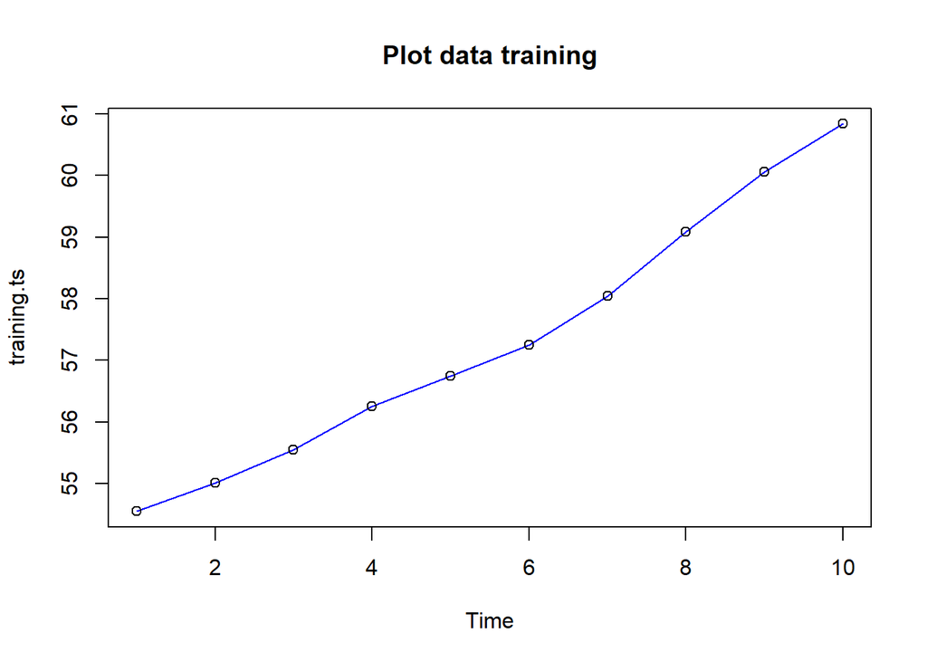

```r
plot(training.ts, col="blue", main="Plot data training")
points(training.ts)
```

Selanjutnya akan dilakukan pemulusan dengan DES, kali ini langsung dicari lambda dan gamma optimum sebagai berikut. Nilai lambda dan gamma optimum dapat dilihat pada smoothing parameters alpha untuk nilai lambda dan beta untuk nilai gamma.

## Model Holt-Winters pada Data Training Papua

```r
# Lamda dan gamma optimum
des.opt <- HoltWinters(training.ts, gamma = FALSE)
des.opt
```

```
## Holt-Winters exponential smoothing with trend and without seasonal component.
##
## Call:
## HoltWinters(x = training.ts, gamma = FALSE)
##
## Smoothing parameters:
##  alpha: 1
##  beta : 1
##  gamma: FALSE
##
## Coefficients:
##    [,1]
## a 60.84
## b  0.78
```

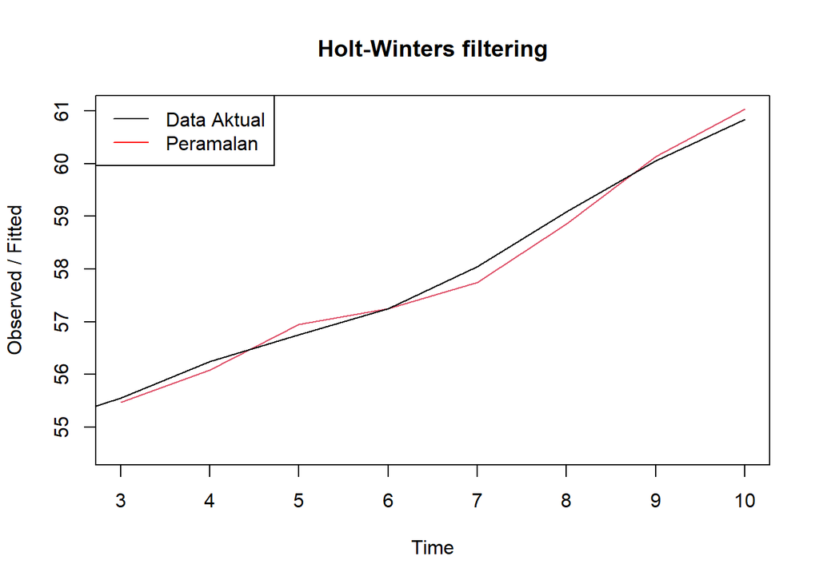

```r
plot(des.opt)
legend("topleft", c("Data Aktual", "Peramalan"), col = c("black", "red"),
       lty = c(1,1))
```

```r
# Ramalan
ramalandesopt <- forecast(des.opt, h=5)
ramalandesopt
```

```
##    Point Forecast    Lo 80    Hi 80    Lo 95    Hi 95
## 11          61.62 61.37888 61.86112 61.25123 61.98877
## 12          62.40 61.86083 62.93917 61.57542 63.22458
## 13          63.18 62.27780 64.08220 61.80021 64.55979
## 14          63.96 62.63932 65.28068 61.94019 65.97981
## 15          64.74 62.95179 66.52821 62.00517 67.47483
```

Selanjutnya akan dicari akurasi dari metode DES.

## Akurasi Model Holt-Winters (λ dan γ optimum)

```r
ssedes.train <- des.opt$SSE
msedes.train <- ssedes.train/length(training.ts)
sisaandes <- ramalandesopt$residuals
head(sisaandes)
```

```
## Time Series:
## Start = 1
## End = 6
## Frequency = 1
## [1]    NA    NA  0.08  0.16 -0.20  0.00
```

```r
mapedes.train <- sum(abs(sisaandes[3:length(training.ts)]/training.ts[3:length(training.ts)])*100)/length(training.ts)

akurasides.opt <- matrix(c(ssedes.train, msedes.train, mapedes.train))
row.names(akurasides.opt) <- c("SSE", "MSE", "MAPE")
colnames(akurasides.opt) <- c("Akurasi lamda dan gamma optimum")
akurasides.opt
```

```
##      Akurasi lamda dan gamma optimum
## SSE                        0.2606000
## MSE                        0.0260600
## MAPE                       0.2132682
```

## Akurasi Data Testing Holt-Winters (λ dan γ optimum)

```r
#Akurasi data testing
selisihdesopt <- ramalandesopt$mean - testing.ts
selisihdesopt
```

```
## Time Series:
## Start = 11
## End = 14
## Frequency = 1
## [1] 0.40 1.00 1.02 0.95
```

```r
SSEtestingdesopt <- sum(selisihdesopt^2)
SSEtestingdesopt <- SSEtestingdesopt/length(testing.ts)
MAPEtestingdesopt <- sum(abs(selisihdesopt/testing.ts)*100)/length(testing.ts)

akurasiDesTesting <- matrix(c(SSEtestingdesopt, SSEtestingdesopt, MAPEtestingdesopt))
row.names(akurasiDesTesting) <- c("SSE", "MSE", "MAPE")
colnames(akurasiDesTesting) <- c("Akurasi lamda dan gamma optimum")
akurasiDesTesting
```

```
##      Akurasi lamda dan gamma optimum
## SSE                         0.775725
## MSE                         0.775725
## MAPE                        1.357667
```

Setelah didapatkan nilai akurasi untuk metode DMA dan DES, selanjutnya akan dibandingkan keakuratan antar metode keduanya.

```r
cbind(akurasi.dma, akurasides.opt)
```

```
##      Akurasi m = 3 Akurasi lamda dan gamma optimum
## SSE      2.0491049                       0.2606000
## MSE      0.2276783                       0.0260600
## MAPE     0.6231418                       0.2132682
```

## Kesimpulan

Berdasarkan hasil perbandingan akurasi, diperoleh bahwa nilai **SSE, MSE, dan MAPE pada metode DES (lamda dan gamma optimum)** lebih kecil dibandingkan dengan metode **DMA (m = 3)**, yaitu:

- **SSE**: 2.0491 (DMA) vs 0.2606 (DES)
- **MSE**: 0.2277 (DMA) vs 0.0261 (DES)
- **MAPE**: 0.6231 (DMA) vs 0.2133 (DES)

Dengan demikian, metode peramalan dan pemulusan terbaik antara keduanya adalah **metode DES**, karena memberikan tingkat kesalahan yang lebih kecil.

Setelah melakukan peramalan, data yang telah dimasukkan kemudian dieksplorasi. Eksplorasi pertama yang dilakukan adalah dengan menggunakan *scatter plot*.

## Eksplorasi Data

### Scatter Plot Tahun vs Nilai IPM Papua

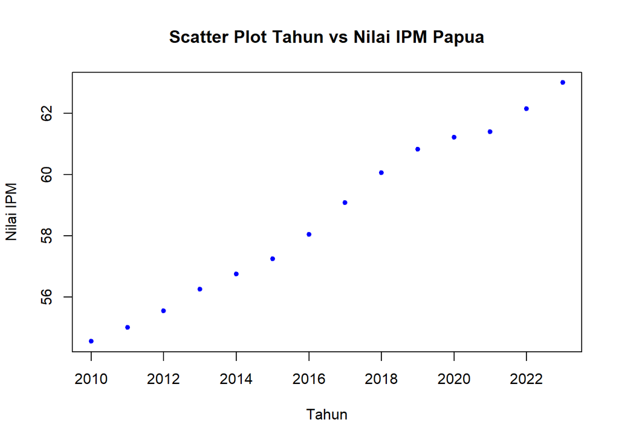

```r
# Pembuatan Scatter Plot
plot(dtPapua$tahun, dtPapua$ipm, pch = 20, col = "blue",
     main = "Scatter Plot Tahun vs Nilai IPM Papua",
     xlab = "Tahun",
     ylab = "Nilai IPM")
```

```r
# Menampilkan Nilai Korelasi
cor(dtPapua$tahun, dtPapua$ipm)
```

```
## [1] 0.9954442
```

Berdasarkan scatter plot di atas, terlihat adanya hubungan / korelasi positif antara peubah tahun dengan nilai IPM, terlihat titik-titik pada plot yang naik ke arah kanan atas. Hal tersebut juga diperkuat dengan hasil perhitungan aplikasi `R` di mana didapatkan nilai korelasi sebesar $0.9954442$.

Setelah mengetahui adanya hubungan antar dua peubah, maka model regresi dapat ditentukan.

## Pembuatan Model Regresi Linear IPM Papua

```r
#Pembuatan Model Regresi
#model regresi
model<- lm(ipm~tahun, data = dtPapua)
summary(model)
```

```
##
## Call:
## lm(formula = ipm ~ tahun, data = dtPapua)
##
## Residuals:
##      Min       1Q   Median       3Q      Max
## -0.39767 -0.21768 -0.03519  0.18168  0.50231
##
## Coefficients:
##               Estimate Std. Error t value Pr(>|t|)
## (Intercept) -1.297e+03  3.750e+01  -34.60 2.16e-13 ***
## tahun        6.725e-01  1.859e-02   36.17 1.28e-13 ***
## ---
## Signif. codes:  0 '***' 0.001 '**' 0.01 '*' 0.05 '.' 0.1 ' ' 1
##
## Residual standard error: 0.2805 on 12 degrees of freedom
## Multiple R-squared:  0.9909, Adjusted R-squared:  0.9902
## F-statistic:  1308 on 1 and 12 DF,  p-value: 1.278e-13
```

## Kesimpulan Regresi Linear

Model yang dihasilkan adalah:

$$y_t = -1297 + 0.6725x_t$$

Berdasarkan ringkasan model dapat diketahui bahwa hasil uji F memiliki *p-value* < $\alpha$ (5%).  
Artinya, minimal terdapat satu variabel yang berpengaruh nyata terhadap model.

Hasil uji-t parsial kedua parameter regresi, yaitu intersep dan koefisien regresi, juga menunjukkan hal yang sama, yaitu memiliki *p-value* < $\alpha$ (5%) sehingga nyata dalam taraf 5%.Selanjutnya dapat dilihat juga nilai $R^2 = 0.9909$.Artinya, sebesar 99.09% keragaman nilai IPM Papua dapat dijelaskan oleh peubah tahun. Hasil ini menunjukkan bahwa model regresi linear sederhana yang diperoleh sangat baik dalam menjelaskan variasi IPM Papua. Namun, langkah selanjutnya perlu dilakukan uji terhadap sisaan untuk memastikan asumsi klasik regresi terpenuhi.

## Diagnostik Regresi

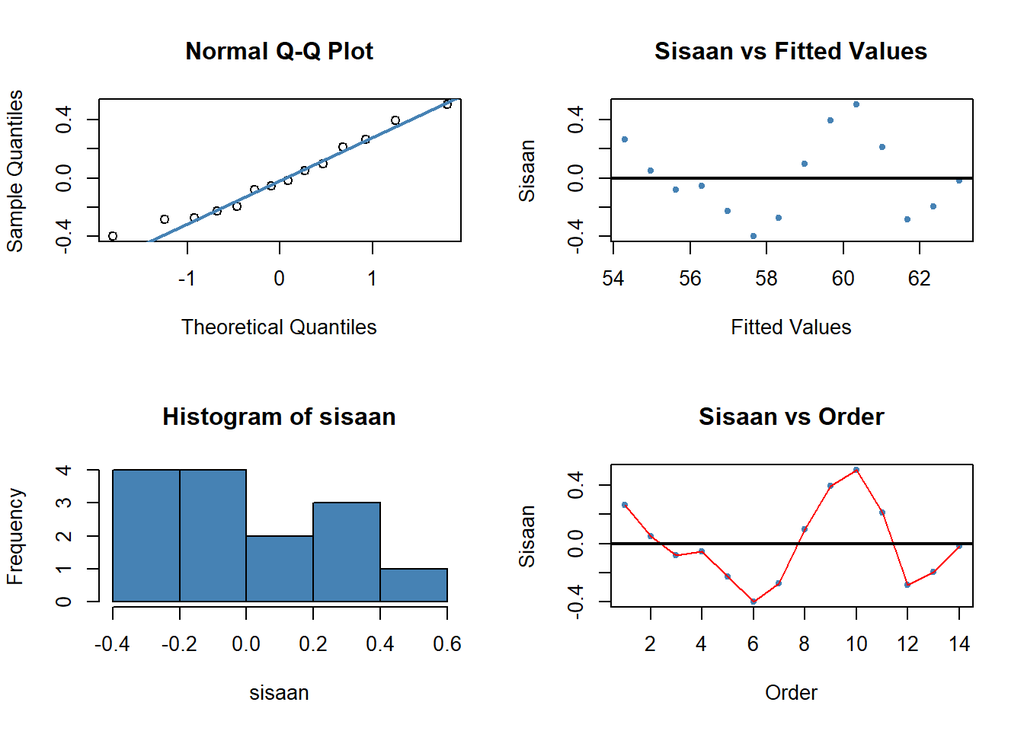

```r
# Sisaan dan fitted value
sisaan <- residuals(model)
fitValue <- predict(model)
# Diagnostik dengan eksploratif
par(mfrow = c(2,2))

# QQ Plot
qqnorm(sisaan)
qqline(sisaan, col = "steelblue", lwd = 2)

# Sisaan vs Fitted Values
plot(fitValue, sisaan, col = "steelblue", pch = 20,
     xlab = "Fitted Values", ylab = "Sisaan",
     main = "Sisaan vs Fitted Values")
abline(a = 0, b = 0, lwd = 2)

# Histogram sisaan
hist(sisaan, col = "steelblue")

# Sisaan vs Order
plot(seq(1, length(sisaan), 1), sisaan, col = "steelblue", pch = 20,
     xlab = "Order", ylab = "Sisaan",
     main = "Sisaan vs Order")
lines(seq(1, length(sisaan), 1), sisaan, col = "red")
abline(a = 0, b = 0, lwd = 2)
```

Dua plot di samping kiri digunakan untuk melihat apakah sisaan menyebar normal. Normal Q-Q Plot di atas menunjukkan bahwa titik-titik sisaan cukup mendekati garis lurus, sehingga dapat dikatakan sisaan cenderung menyebar normal. Namun, histogram dari sisaan terlihat agak menyebar rata dan tidak terlalu jelas membentuk pola distribusi normal. Selanjutnya, dua plot di samping kanan digunakan untuk melihat autokorelasi. Plot Sisaan vs Fitted Values menunjukkan bahwa sisaan menyebar cukup merata di sekitar garis nol tanpa pola tertentu, sehingga tidak ada indikasi kuat terjadinya heteroskedastisitas. Namun, untuk memastikannya perlu uji formal. Secara umum, hasil diagnostik awal menunjukkan bahwa asumsi normalitas relatif terpenuhi, sementara autokorelasi belum dapat dipastikan dan perlu diuji lebih lanjut menggunakan plot ACF dan PACF.

```r
#Melihat Sisaan Menyebar Normal/Tidak
#H0: sisaan mengikuti sebaran normal
#H1: sisaan tidak mengikuti sebaran normal
shapiro.test(sisaan)
```

```
##
##  Shapiro-Wilk normality test
##
## data:  sisaan
## W = 0.96434, p-value = 0.7934
```

[output not shown]

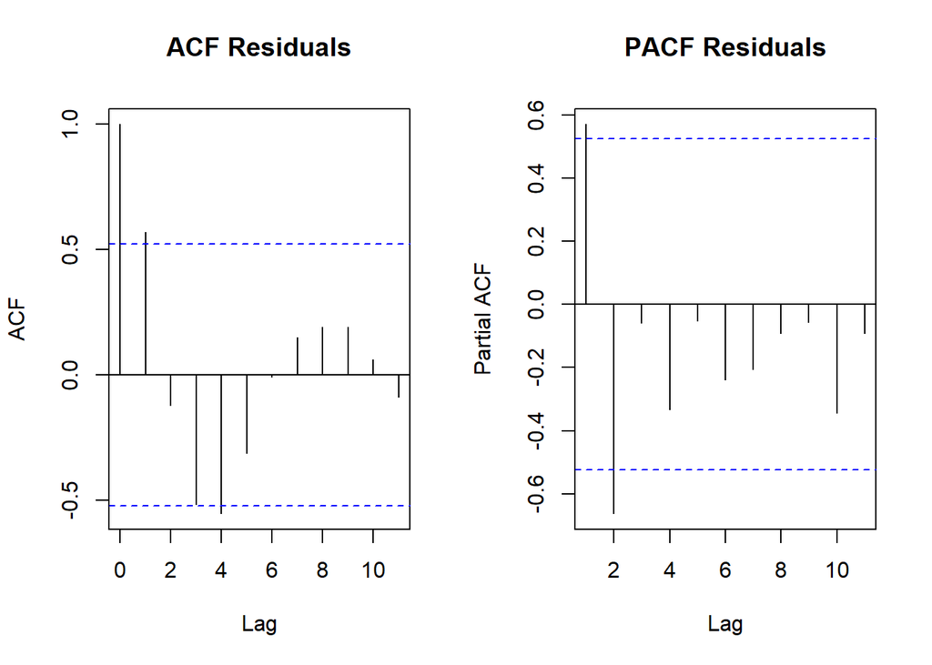

```r
# Residual dari model linear IPM ~ Tahun
model <- lm(ipm ~ tahun, data=dtPapua)
residuals_model <- residuals(model)
# ACF dan PACF untuk identifikasi autokorelasi
par(mfrow = c(1,2))
acf(residuals_model, main="ACF Residuals")
pacf(residuals_model, main="PACF Residuals")
```

```r
#Deteksi autokorelasi dengan uji-Durbin Watson
#H0: tidak ada autokorelasi
#H1: ada autokorelasi
dwtest(model)
```

```
##
##  Durbin-Watson test
##
## data:  model
## DW = 0.78568, p-value = 0.00116
## alternative hypothesis: true autocorrelation is greater than 0
```

```r
#Penanganan Autokorelasi Cochrane-Orcutt
modelCO<-cochrane.orcutt(model)
modelCO
```

```
## Cochrane-orcutt estimation for first order autocorrelation
##
## Call:
## lm(formula = ipm ~ tahun, data = dtPapua)
##
##  number of interaction: 8
##  rho 0.569137
##
## Durbin-Watson statistic
## (original):    0.78568 , p-value: 1.16e-03
## (transformed): 1.06925 , p-value: 1.228e-02
##
##  coefficients:
##  (Intercept)        tahun
## -1343.402307     0.695248
```

```r
#Rho optimum
rho<- modelCO$rho
rho
```

```
## [1] 0.5691367
```

Selanjutnya akan dilakukan transformasi secara manual dengan syntax berikut ini.

```r
ipm
```

```
##  [1] 54.55 55.01 55.55 56.25 56.75 57.25 58.05 59.09 60.06 60.84 61.22 61.40
## [13] 62.16 63.01
```

```r
ipm[-1]
```

```
##  [1] 55.01 55.55 56.25 56.75 57.25 58.05 59.09 60.06 60.84 61.22 61.40 62.16
## [13] 63.01
```

```r
#Transformasi Manual
ipm.trans<- ipm[-1]-ipm[-12]*rho
tahun.trans<- tahun[-1]-tahun[-12]*rho
modelCOmanual<- lm(ipm.trans~tahun.trans)
summary(modelCOmanual)
```

```
##
## Call:
## lm(formula = ipm.trans ~ tahun.trans)
##
## Residuals:
##      Min       1Q   Median       3Q      Max
## -0.39532 -0.07534 -0.02983  0.04916  0.36474
##
## Coefficients:
##               Estimate Std. Error t value Pr(>|t|)
## (Intercept) -571.52330   35.96217  -15.89 6.19e-09 ***
## tahun.trans    0.68684    0.04136   16.61 3.89e-09 ***
## ---
## Signif. codes:  0 '***' 0.001 '**' 0.01 '*' 0.05 '.' 0.1 ' ' 1
##
## Residual standard error: 0.2225 on 11 degrees of freedom
## Multiple R-squared:  0.9616, Adjusted R-squared:  0.9582
## F-statistic: 275.8 on 1 and 11 DF,  p-value: 3.886e-09
```

```r
#Mencari Penduga Koefisien Regresi setelah Transformasi ke Persamaan Awal
b0bintang <- modelCOmanual$coefficients[-2]
b0 <- b0bintang/(1-rho)
b1 <- modelCOmanual$coefficients[-1]
b0
```

```
## (Intercept)
##   -1326.461
```

```r
b1
```

```
## tahun.trans
##   0.6868425
```

## Metode Hildreth-Lu

Penanganan kedua adalah menggunakan metode Hildreth-Lu. Metode ini akan mencari nilai SSE terkecil dan dapat dicari secara manual maupun menggunakan packages. Jika menggunakan packages, gunakan `library` *packages* `HORM`.

```r
library(HoRM)

# ambil y dan x (satu prediktor saja)
y <- dtPapua$ipm
x <- dtPapua$tahun

# grid search rho 0–0.9
r <- seq(0, 0.9, by = 0.1)
tab <- data.frame(
  rho = r,
  SSE = sapply(r, function(rr) deviance(hildreth.lu(y, x, rr)))
)

tab            # tabel rho vs SSE
```

```
##    rho       SSE
## 1  0.0 0.8495115
## 2  0.1 0.7515483
## 3  0.2 0.6724555
## 4  0.3 0.6122330
## 5  0.4 0.5708810
## 6  0.5 0.5483995
## 7  0.6 0.5447883
## 8  0.7 0.5600475
## 9  0.8 0.5941772
## 10 0.9 0.6471773
```

```r
rho_hat <- tab$rho[which.min(tab$SSE)]   # rho terbaik
fit_hl  <- hildreth.lu(y, x, rho_hat)    # model final
summary(fit_hl)
```

```
##
## Call:
## lm(formula = y ~ x)
##
## Residuals:
##      Min       1Q   Median       3Q      Max
## -0.42651 -0.09973 -0.02670  0.06193  0.34784
##
## Coefficients:
##               Estimate Std. Error t value Pr(>|t|)
## (Intercept) -538.73849   33.29748  -16.18 5.12e-09 ***
## x              0.69695    0.04124   16.90 3.23e-09 ***
## ---
## Signif. codes:  0 '***' 0.001 '**' 0.01 '*' 0.05 '.' 0.1 ' ' 1
##
## Residual standard error: 0.2225 on 11 degrees of freedom
## Multiple R-squared:  0.9629, Adjusted R-squared:  0.9595
## F-statistic: 285.6 on 1 and 11 DF,  p-value: 3.229e-09
```

```r
#Penanganan Autokorelasi Hildreth lu
# Hildreth-Lu
hildreth.lu.func<- function(r, model){
  x <- model.matrix(model)[,-1]
  y <- model.response(model.frame(model))
  n <- length(y)
  t <- 2:n
  y <- y[t]-r*y[t-1]
  x <- x[t]-r*x[t-1]

  return(lm(y~x))
}

#Pencarian rho yang meminimumkan SSE
r <- c(seq(0.1,0.9, by= 0.1))
tab <- data.frame("rho" = r, "SSE" = sapply(r, function(i){deviance(hildreth.lu.func(i, model))}))
round(tab, 4)
```

```
##   rho    SSE
## 1 0.1 0.7515
## 2 0.2 0.6725
## 3 0.3 0.6122
## 4 0.4 0.5709
## 5 0.5 0.5484
## 6 0.6 0.5448
## 7 0.7 0.5600
## 8 0.8 0.5942
## 9 0.9 0.6472
```

```r
#Rho optimal di sekitar 0.6
rOpt <- seq(0.4,0.8, by= 0.001)
tabOpt <- data.frame("rho" = rOpt, "SSE" = sapply(rOpt, function(i){deviance(hildreth.lu.func(i, model))}))
head(tabOpt[order(tabOpt$SSE),])
```

```
##       rho       SSE
## 170 0.569 0.5438896
## 171 0.570 0.5438902
## 169 0.568 0.5438908
## 172 0.571 0.5438928
## 168 0.567 0.5438938
## 173 0.572 0.5438973
```

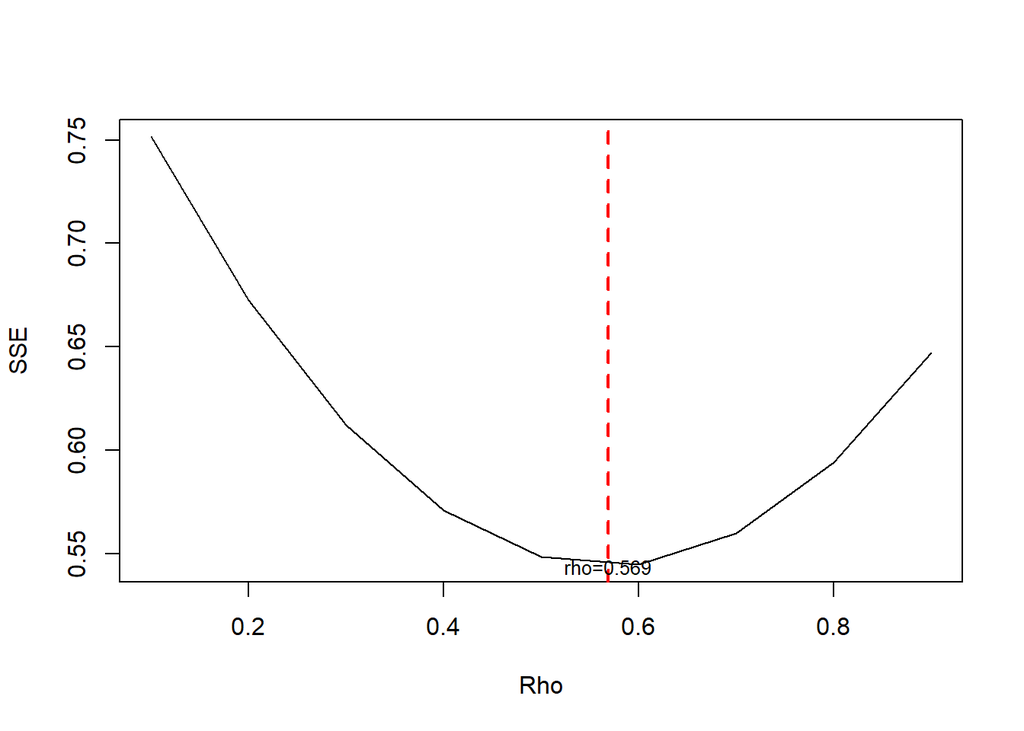

```r
#Grafik SSE optimum
par(mfrow = c(1,1))
plot(tab$SSE ~ tab$rho , type = "l", xlab = "Rho", ylab = "SSE")
abline(v = tabOpt[tabOpt$SSE==min(tabOpt$SSE),"rho"], lty = 2, col="red",lwd=2)
text(x=0.569, y=0.5438896, labels = "rho=0.569", cex = 0.8)
```

Perhitungan yang dilakukan aplikasi `R` menunjukkan bahwa nilai $ρ$ optimum, yaitu saat SSE terkecil terdapat pada nilai $ρ=0.569$. Hal tersebut juga ditunjukkan pada plot. Selanjutnya, model dapat didapatkan dengan mengevaluasi nilai $ρ$ ke dalam fungsi `hildreth.lu.func`, serta dilanjutkan dengan pengujian autokorelasi dengan uji Durbin-Watson. Namun, setelah pengecekan tersebut tidak lupa koefisien regresi tersebut digunakan untuk transformasi balik. Persamaan hasil transformasi itulah yang menjadi persamaan sesungguhnya.

```r
# Model terbaik
modelHL <- hildreth.lu.func(0.569, model)
summary(modelHL)
```

```
##
## Call:
## lm(formula = y ~ x)
##
## Residuals:
##      Min       1Q   Median       3Q      Max
## -0.42013 -0.08426 -0.01841  0.05571  0.35079
##
## Coefficients:
##               Estimate Std. Error t value Pr(>|t|)
## (Intercept) -579.00030   33.26704  -17.41 2.36e-09 ***
## x              0.69524    0.03824   18.18 1.48e-09 ***
## ---
## Signif. codes:  0 '***' 0.001 '**' 0.01 '*' 0.05 '.' 0.1 ' ' 1
##
## Residual standard error: 0.2224 on 11 degrees of freedom
## Multiple R-squared:  0.9678, Adjusted R-squared:  0.9649
## F-statistic: 330.5 on 1 and 11 DF,  p-value: 1.484e-09
```

```r
# Transformasi Balik
cat("y = ", coef(modelHL)[1]/(1-0.569), " + ", coef(modelHL)[2], "x", sep = "")
```

```
## y = -1343.388 + 0.6952413x
```

```r
#Deteksi autokorelasi
dwtest(modelHL)
```

```
##
##  Durbin-Watson test
##
## data:  modelHL
## DW = 1.0692, p-value = 0.01228
## alternative hypothesis: true autocorrelation is greater than 0
```

Terakhir, akan dibandingkan nilai SSE dari ketiga metode (metode awal, metode Cochrane-Orcutt, dan Hildreth-Lu).

```r
#Perbandingan
sseModelawal <- anova(model)$`Sum Sq`[-1]
sseModelCO <- anova(modelCOmanual)$`Sum Sq`[-1]
sseModelHL <- anova(modelHL)$`Sum Sq`[-1]
mseModelawal <- sseModelawal/length(ipm)
mseModelCO <- sseModelCO/length(ipm)
mseModelHL <- sseModelHL/length(ipm)
akurasi <- matrix(c(sseModelawal,sseModelCO,sseModelHL,
                    mseModelawal,mseModelCO,mseModelHL),nrow=2,ncol=3,byrow = T)
colnames(akurasi) <- c("Model Awal", "Model Cochrane-Orcutt", "Model Hildreth-Lu")
row.names(akurasi) <- c("SSE","MSE")
akurasi
```

```
##     Model Awal Model Cochrane-Orcutt Model Hildreth-Lu
## SSE 0.94394330            0.54452205        0.54388956
## MSE 0.06742452            0.03889443        0.03884925
```

Berdasarkan hasil tersebut dapat diketahui bahwa hasil penanganan autokorelasi dengan metode Cochrane-Orcutt dan Hildreth-Lu memiliki SSE yang sama, sebesar $0.54452205$

# Hasil Keluaran Cochrane-Orcutt dan Hildreth-Lu

Hasil keluaran model setelah dilakukan penanganan menggunakan Cochrane-Orcutt dan Hildreth-Lu adalah sebagai berikut:

$$\hat{y}_i = \frac{\text{Intercept}}{1-\hat{\rho}} + \text{Slope} \cdot
x_t$$

Berdasarkan hasil *Cochrane-Orcutt* / *Hildreth-Lu*, nilai koefisien yang diperoleh adalah:

- Intercept: -579.0002952
- Slope: 0.6952413
- Rho optimum ($\hat{\rho}$): 0.569137

Sehingga persamaan transformasi balik menjadi:

```r
cat("y = ", coef(modelHL)[1]/(1-0.569137), " + ", coef(modelHL)[2], " x_t", sep = "")
```

```
## y = -1343.815 + 0.6952413 x_t
```

## Kesimpulan AKhir

Berdasarkan hasil analisis menggunakan dua metode (Cochrane-Orcutt dan Hildreth-Lu), terlihat bahwa kedua metode **belum mampu sepenuhnya menangani autokorelasi** pada model IPM ~ Tahun.

Setelah dilakukan koreksi:  
- Nilai **Durbin-Watson meningkat**, menunjukkan autokorelasi menurun,  
- Nilai **SSE dan MSE berkurang**, menunjukkan model lebih baik dalam fitting.

Namun, autokorelasi **tidak hilang sepenuhnya** dan SSE masih ada, sehingga **model belum valid**.

Artinya, untuk memperoleh model yang lebih akurat, **diperlukan pendekatan lain**, misalnya dengan model time series yang lebih kompleks atau transformasi variabel tambahan.